# Introduction to R - Data visualization 101

MSE Core Module 1.1

Federico Marini

marinif@uni-mainz.de

Institute of Medical Biostatistics, Epidemiology and Informatics (IMBEI), Mainz, Germany

October 16, 2026

# Previously on these screens

- Factors, missing data, dates!
- Some good habits to have
- A constant suggestion to inspect and view your data

## Let’s get all set for this chapter!

```r
library("dplyr")
library("tidyr")
library("gapminder")
library("ggplot2")

# checkpoint from chapter 4, with the factor order from chapter 5
nh <- readRDS("datasets/nhanes_ghb.RDS") |>
  mutate(bmi_class = factor(bmi_class,
                            levels = c("underweight", "normal", "overweight", "obese")))
```

Who of you has used R already to plot something? What did you use?

Yes, R has a lot of possibilities to plot and visualize data!

Base R has the almighty `plot()` function, which you might have already started loving & hating

I am giving you a gentle introduction to the `gg` - the Grammar of Graphics

# 1. ggplot basics

## The grammar: a plot is built from layers

```r
ggplot(data = nh, mapping = aes(x = Age, y = BMI)) +
  geom_point()
```

- **data**: which table
- **aes()**: which columns go where (x, y, colour, size, …)
- **geom_…()**: how to draw them (points, bars, boxes, …)
- layers are added with `+`

Something inside `aes()` will be mapped to the data, outside of it will be treated as a constant

What `aes`thetics can you think of right now?

## Start empty, add layer by layer

```r
ggplot(nh)                            # nothing to see
ggplot(nh, aes(x = Age, y = BMI))     # axes appear, no data drawn (data "limits" are known)
ggplot(nh, aes(x = Age, y = BMI)) + geom_point()
```

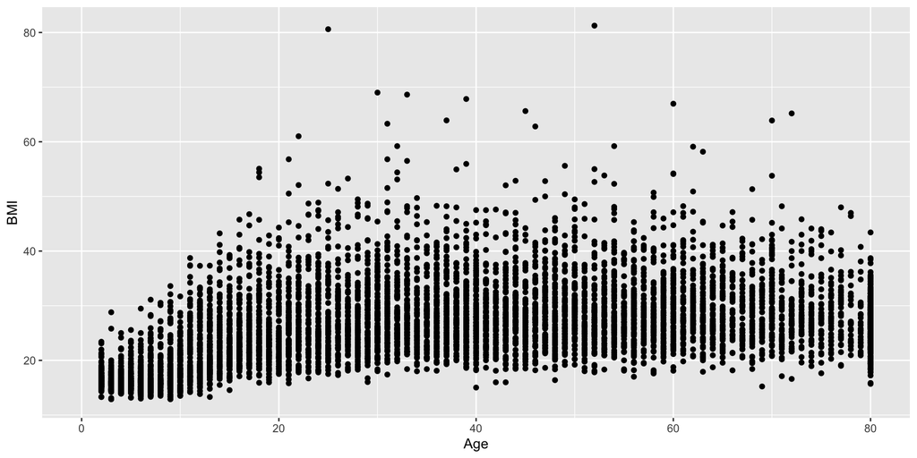

## One variable: histogram

```r
ggplot(nh, aes(x = BMI)) +
  geom_histogram(bins = 30)

ggplot(nh, aes(x = BMI)) +
  geom_histogram(binwidth = 2)
```

Does the shape change?

What alternatives to the simple histogram do you know?

## Two variables: scatter plot

In this case, two continuous variables

Why am I using alpha? Try without that!

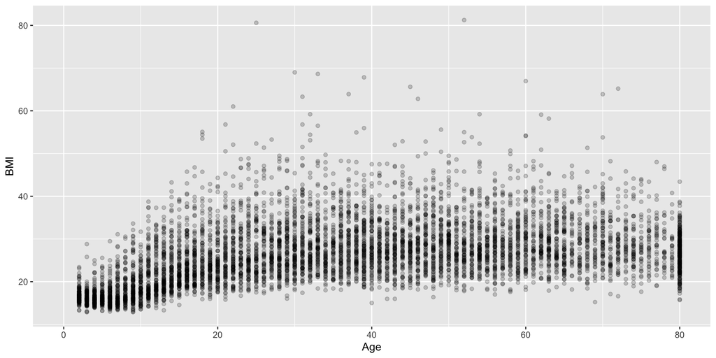

```r
ggplot(nh, aes(x = Age, y = BMI)) +
  geom_point(alpha = 0.2)
```

## Add more aesthetics

Look at the placement of the `colour`:

```r
ggplot(nh, aes(x = Age, y = BMI, colour = sex)) +
  geom_point(alpha = 0.3)

ggplot(nh, aes(x = Age, y = BMI)) +
  geom_point(colour = "steelblue", alpha = 0.3)
```

What changed?

## Facets: one panel per group

You’ll probably learn to love small multiples

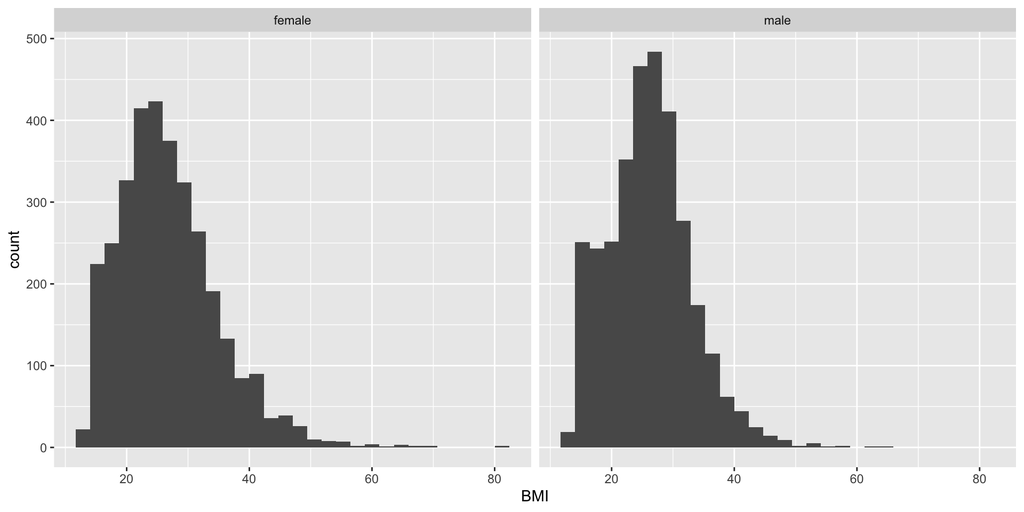

```r
ggplot(nh, aes(x = BMI)) +
  geom_histogram(bins = 30) +
  facet_wrap(~ sex)
```

## Labels and themes

Controlling the aspect of the side dishes is important as well!

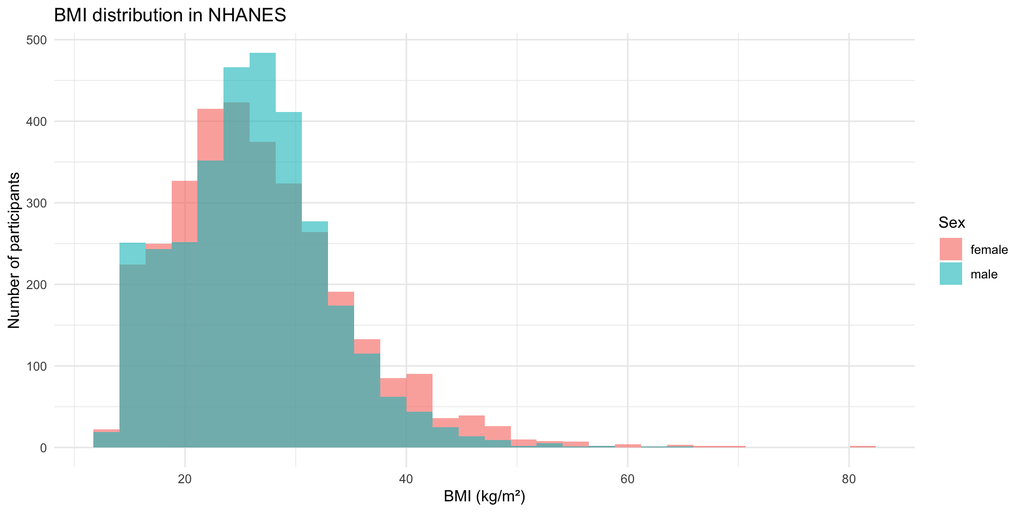

```r
ggplot(nh, aes(x = BMI, fill = sex)) +
  geom_histogram(bins = 30, alpha = 0.6, position = "identity") +
  labs(title = "BMI distribution in NHANES",
       x = "BMI (kg/m²)", y = "Number of participants",
       fill = "Sex") +
  theme_minimal()
```

Themes - an excellent and comfy way to change the looks of a plot. There are many collections of themes out there

## Save that plot!

Each plot done via `ggplot` is returned as an object (and printed)

… and objects can be saved - how to do this efficiently?

```r
p <- ggplot(nh, aes(x = BMI)) + geom_histogram(bins = 30)
p
ggsave(p, filename = "bmi_hist.png", width = 6, height = 4, dpi = 300)
```

You can also use the RStudio interface, but I would heartily recommend *against* that.

# 2. Previous chapters, now as plots

## Chapter 3 flavour: distributions by group

Let’s have a look at the relationship between systolic blood pressure and smoking habits!

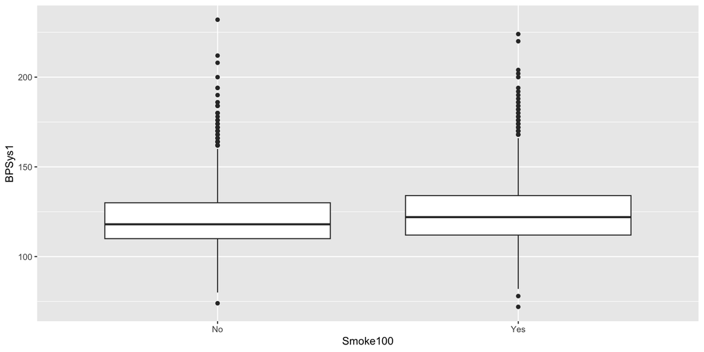

```r
nh |>
  drop_na(BPSys1, Smoke100) |>
  ggplot(aes(x = Smoke100, y = BPSys1)) +
  geom_boxplot()
```

Is this a fair comparison? What did we forget about age (chapter 5)?

## Adults only, split by age group

We will use the facets here…

Let’s try here some other `geom_`s!

`geom_jitter()`, `geom_violin()`, `ggforce::geom_sina` are just some of my favourites

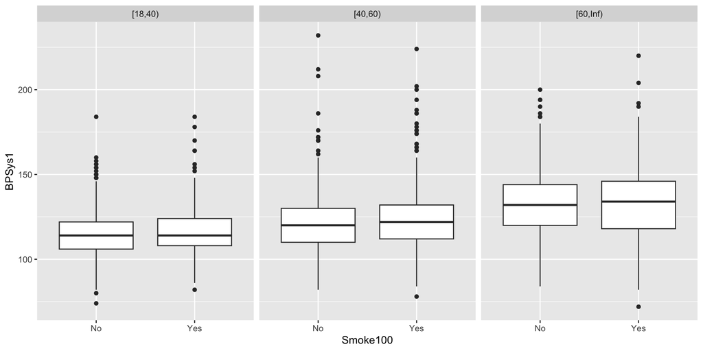

```r
nh |>
  filter(Age >= 18) |>
  drop_na(BPSys1, Smoke100) |>
  ggplot(aes(x = Smoke100, y = BPSys1)) +
  geom_boxplot() +
  facet_wrap(~ age_group)
```

## Chapter 4: the guiding question

Remember that? “What is the prevalence of diabetes by BMI category, and how does it compare with HbA1c?”

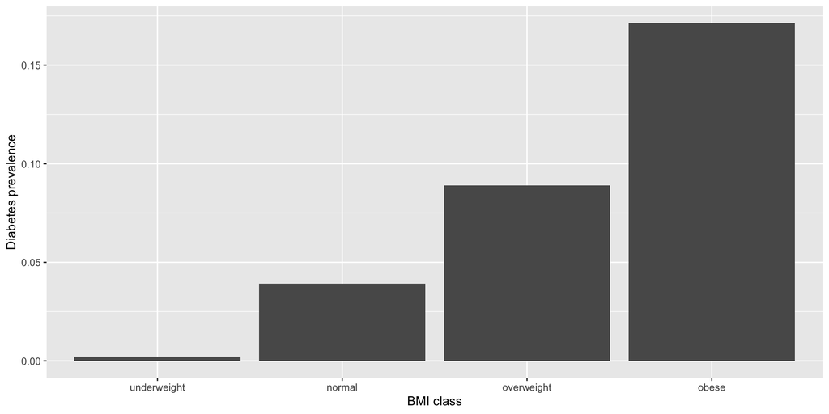

```r
nh |>
  drop_na(bmi_class, Diabetes) |>
  group_by(bmi_class) |>
  summarise(prevalence = mean(Diabetes == "Yes")) |>
  ggplot(aes(x = bmi_class, y = prevalence)) +
  geom_col() +
  labs(x = "BMI class", y = "Diabetes prevalence")
```

## … by age group too

Well, while we are at it…

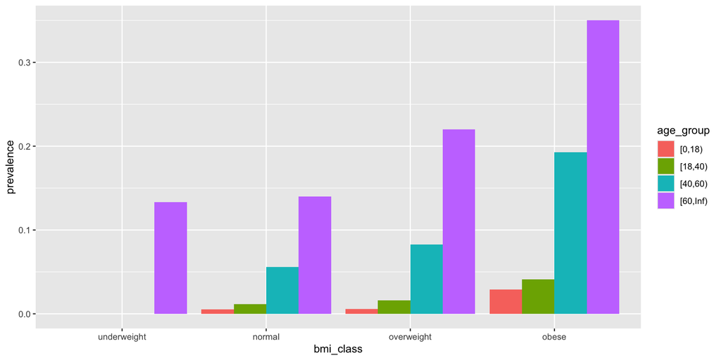

```r
nh |>
  drop_na(bmi_class, Diabetes, age_group) |>
  group_by(age_group, bmi_class) |>
  summarise(prevalence = mean(Diabetes == "Yes"), .groups = "drop") |>
  ggplot(aes(x = bmi_class, y = prevalence, fill = age_group)) +
  geom_col(position = "dodge")
```

## HbA1c vs. diabetes status

The `geom_sina()` shows the density distribution AND individual observations

*Does this make sense?*

I know it sounds obvious and possibly naif - but don’t you ever forget to ask this question, every now and then. And especially after generating a result ^_^

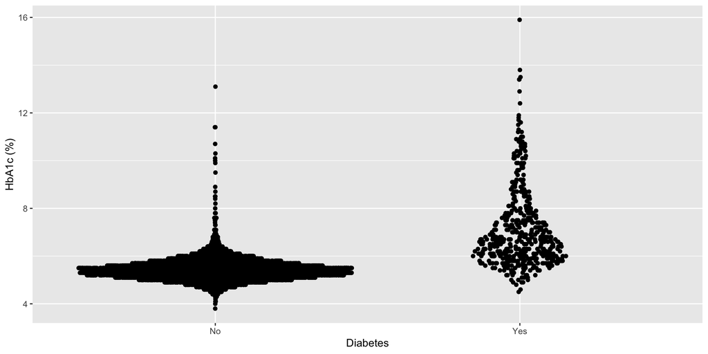

```r
nh |>
  drop_na(LBXGH, Diabetes) |>
  ggplot(aes(x = Diabetes, y = LBXGH)) +
  ggforce::geom_sina() +
  labs(y = "HbA1c (%)")
```

## Chapter 5: missing values

Let’s **see** the proportion of missing data

One plot vs one table - who wins?

Immediateness vs precision?

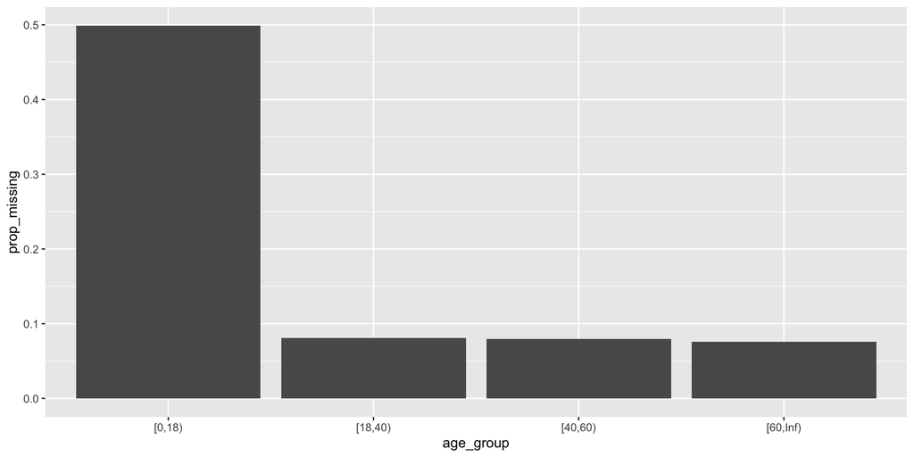

```r
nh |>
  mutate(bp_missing = is.na(BPSys1)) |>
  group_by(age_group) |>
  summarise(prop_missing = mean(bp_missing)) |>
  ggplot(aes(x = age_group, y = prop_missing)) +
  geom_col()
```

## Chapter 5: the epi curve

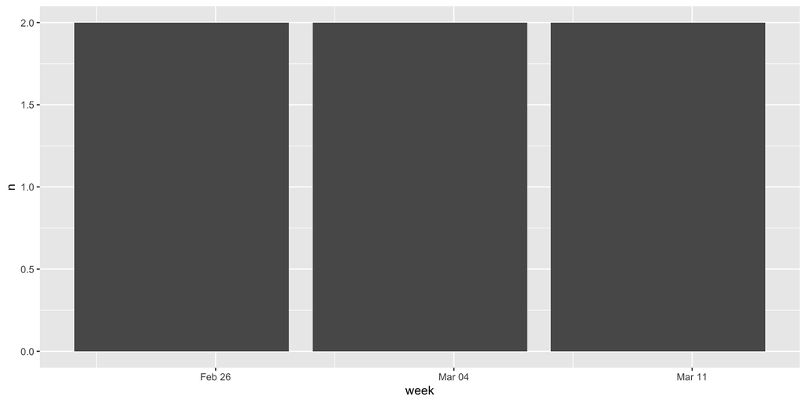

```r
library("lubridate")
linelist <- tibble(
  id    = 1:6,
  onset = ymd(c("2024-03-01", "2024-03-02", "2024-03-05",
                "2024-03-09", "2024-03-10", "2024-03-12"))
)

linelist |>
  mutate(week = floor_date(onset, "week")) |>
  count(week) |>
  ggplot(aes(x = week, y = n)) +
  geom_col()
```

## Challenges

**Challenge: create your own plot**

Pick **two NHANES variables** and make a plot you would be happy to show a colleague:

- a sensible geom for the variable types
- a title and clear axis labels
- one extra aesthetic (colour or facet)
- **one sentence** under the plot saying what it shows

**Challenge: improve it**

- Reorder the levels of `Education` and plot it as a bar chart
- Add `geom_smooth()` to the scatter plot of `Age` vs `BMI`
- Change colours with `scale_fill_brewer()` or `scale_colour_viridis_d()`

I can only recommend to have a look at least once at this: https://apreshill.github.io/ohsu-biodatavis/slides.html

# 3. A famous example: the `gapminder` dataset

## Time to chillax a bit

[video not shown]

*Hans Rosling, TED 2006*

## The `gapminder` data, in R

```r
library("gapminder")
glimpse(gapminder)
```

```
Rows: 1,704
Columns: 6
$ country   <fct> "Afghanistan", "Afghanistan", "Afghanistan", "Afghanistan", …
$ continent <fct> Asia, Asia, Asia, Asia, Asia, Asia, Asia, Asia, Asia, Asia, …
$ year      <int> 1952, 1957, 1962, 1967, 1972, 1977, 1982, 1987, 1992, 1997, …
$ lifeExp   <dbl> 28.801, 30.332, 31.997, 34.020, 36.088, 38.438, 39.854, 40.8…
$ pop       <int> 8425333, 9240934, 10267083, 11537966, 13079460, 14880372, 12…
$ gdpPercap <dbl> 779.4453, 820.8530, 853.1007, 836.1971, 739.9811, 786.1134, …
```

```r
gapminder |>
  filter(year == 2007) |>
  count(continent)
```

```
# A tibble: 5 × 2
  continent     n
  <fct>     <int>
1 Africa       52
2 Americas     25
3 Asia         33
4 Europe       30
5 Oceania       2
```

## One year, three variables

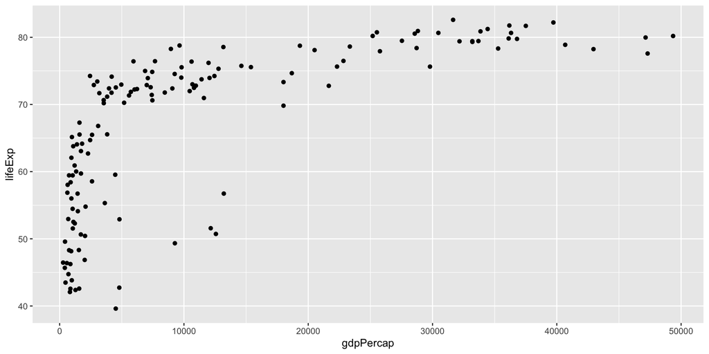

```r
gapminder |>
  filter(year == 2007) |>
  ggplot(aes(x = gdpPercap, y = lifeExp)) +
  geom_point()
```

## Make it readable: log scale

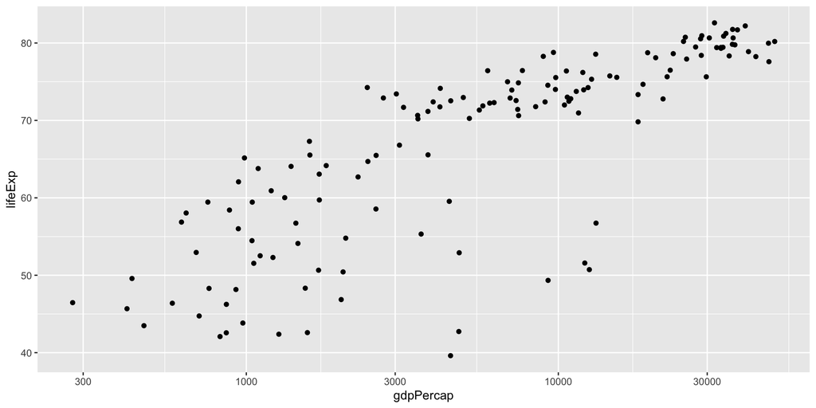

```r
gapminder |>
  filter(year == 2007) |>
  ggplot(aes(x = gdpPercap, y = lifeExp)) +
  geom_point() +
  scale_x_log10()
```

## Using more: colour and size

Let’s see more than in just two dimensions! - `aes()` FTW!

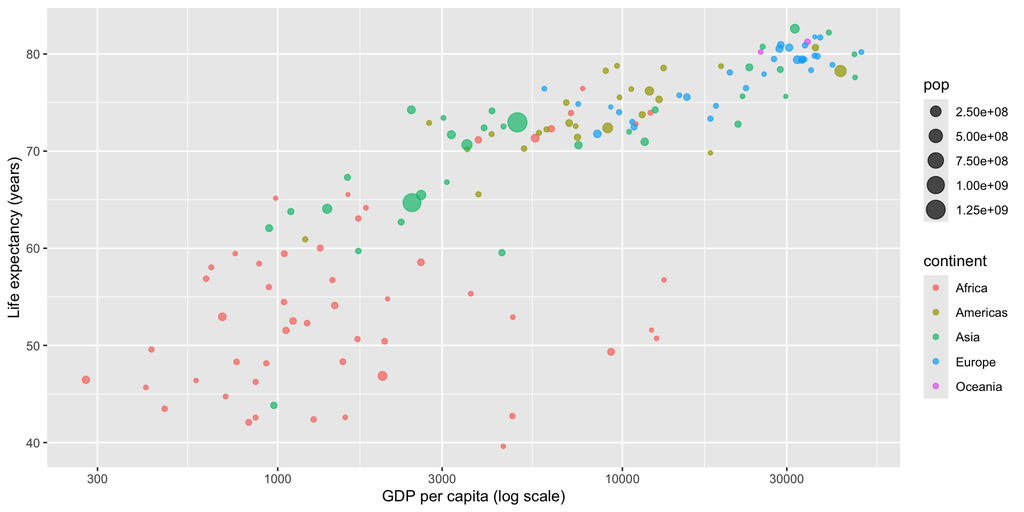

```r
gapminder |>
  filter(year == 2007) |>
  ggplot(aes(x = gdpPercap, y = lifeExp,
             colour = continent, size = pop)) +
  geom_point(alpha = 0.7) +
  scale_x_log10() +
  labs(x = "GDP per capita (log scale)", y = "Life expectancy (years)")
```

## Let’s add time to the picture!

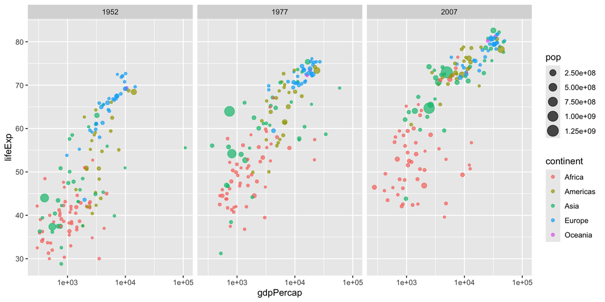

```r
# static version: one panel per year
gapminder |>
  filter(year %in% c(1952, 1977, 2007)) |>
  ggplot(aes(x = gdpPercap, y = lifeExp, colour = continent, size = pop)) +
  geom_point(alpha = 0.7) +
  scale_x_log10() +
  facet_wrap(~ year) -> p
p
```

## Let’s make that interactive!

```r
plotly::ggplotly(p)
```

[interactive chart not shown]

## Here’s a live version!

```r
library("gganimate")

anim <- gapminder |>
  ggplot(aes(x = gdpPercap,
             y = lifeExp,
             colour = continent,
             size = pop)) +
  geom_point(alpha = 0.7) +
  scale_x_log10() +
  theme_bw() +
  labs(title = "Year: {frame_time}", x = "GDP per capita", y = "Life expectancy") +
  transition_time(year) +
  ease_aes('linear')
```

The last lines are the relevant portions - can you guess what will happen?

## Here’s a live version!

```r
anim
```

```r
# anim_save("gapminder.gif", animate(anim, width = 800, height = 500))
```

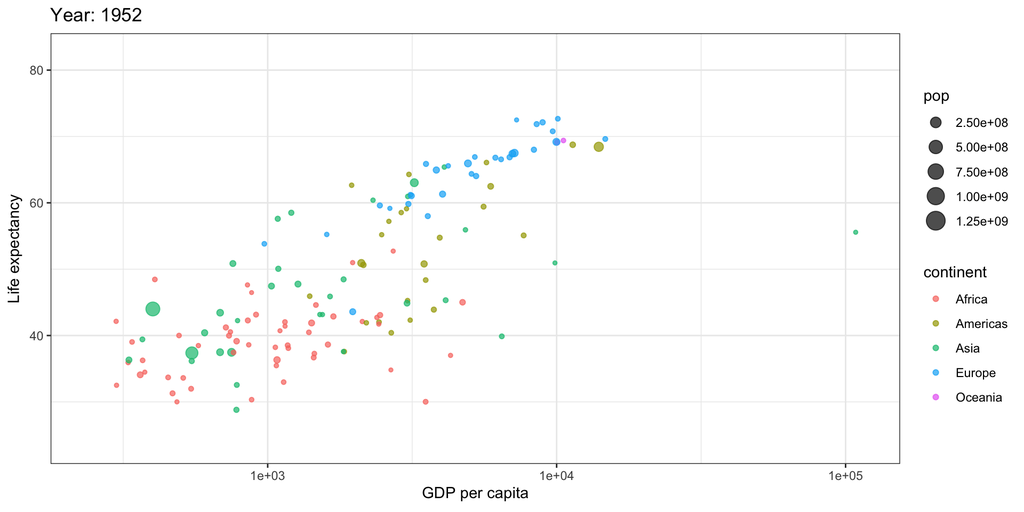

# Wrap-up

## What you can do now

- Read, clean, transform, and combine data
- Look at it with plots
- Put it all in a document that renders from top to bottom

### Some good resources

- “From data to viz” - https://www.data-to-viz.com/
- The R graph gallery - https://r-graph-gallery.com/
- Actually, many good resources out there!
  - I’m a fanboy - check out the work of Nadieh Bremer, Nicola Rennie, Nathan Yau, Tamara Münzner, …

# What comes next?

Ask me anything!

**Questions** on this, or on any of the previous chapters?

**Thank you for your attention!**